# Mobile Game AB Test

Zihao Zhou

6/22/2020

## Data&Game Summary

- Cookie Cats is a hugely popular mobile puzzle game developed by Tactile Entertainment. It’s a classic “connect three”-style puzzle game where the player must connect tiles of the same color to clear the board and win the level.
  - userid - a unique number that identifies each player.
  - version - whether the player was put in the control group (gate_30 - a gate at level 30) or the group with the moved gate (gate_40 - a gate at level 40).
  - sum_gamerounds - the number of game rounds played by the player during the first 14 days after install.
  - retention_1 - did the player come back and play 1 day after installing?
  - retention_7 - did the player come back and play 7 days after installing?
  - When a player installed the game, he or she was randomly assigned to either gate_30 or gate_40. As a sanity check, let’s see if there are roughly the same number of players in each AB group.

```r
rmarkdown::paged_table(Mobile)
```

| userid | version | sum_gamerounds | retention_1 | retention_7 |
| --- | --- | --- | --- | --- |
| 116 | gate_30 | 3 | FALSE | FALSE |
| 337 | gate_30 | 38 | TRUE | FALSE |
| 377 | gate_40 | 165 | TRUE | FALSE |
| 483 | gate_40 | 1 | FALSE | FALSE |
| 488 | gate_40 | 179 | TRUE | TRUE |
| 540 | gate_40 | 187 | TRUE | TRUE |
| 1066 | gate_30 | 0 | FALSE | FALSE |
| 1444 | gate_40 | 2 | FALSE | FALSE |
| 1574 | gate_40 | 108 | TRUE | TRUE |
| 1587 | gate_40 | 153 | TRUE | FALSE |

[output cut: 9990 more lines]

## Experiment and Control

- First of all, let us take a look at how many people separated into the two versions.

```r
rmarkdown::paged_table(Mobile %>%
  group_by(version) %>%
  summarise(Count = n()))
```

| version | Count |
| --- | --- |
| gate_30 | 44700 |
| gate_40 | 45489 |

The data we have is from 90,189 players that installed the game while the AB-test was running. There are 44,700 players at a gate level of 30. There are 45,489 players at a gate level of 40. First, let us take a look at the distribution of game rounds of the two versions.

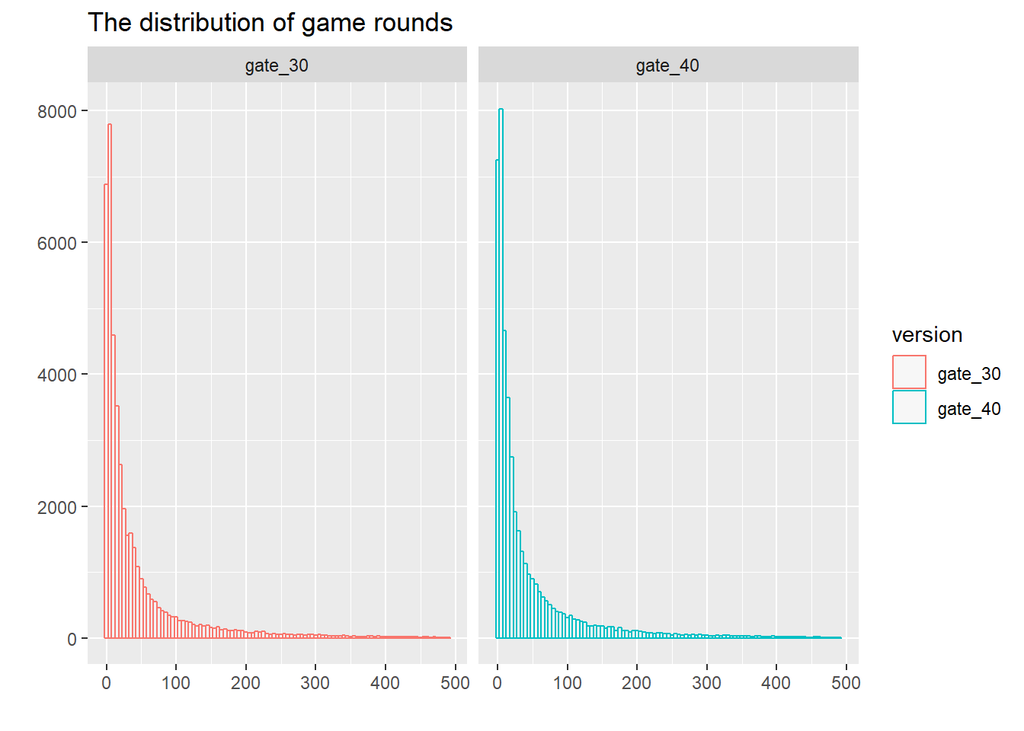

```r
Mobile %>%
  filter(sum_gamerounds < quantile(Mobile$sum_gamerounds, 0.99)) %>%
  ggplot(aes(x=sum_gamerounds,color = version, fill=version )) + facet_grid(~version) + geom_histogram(fill="white", alpha=0.4, position="dodge", binwidth = 5) + ggtitle('The distribution of game rounds') + labs(x='',y='')
```

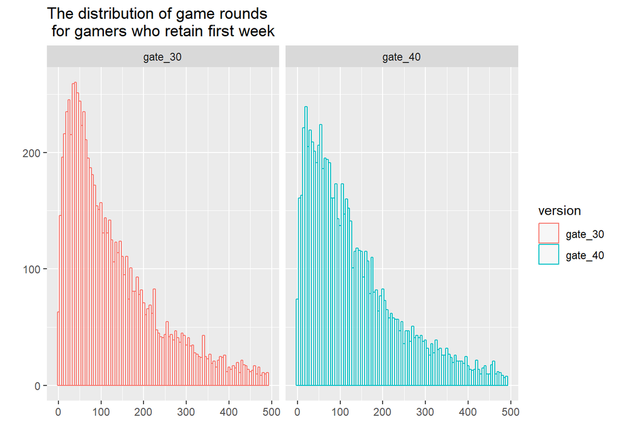

```r
Mobile %>%
  filter(retention_7 == T) %>%
  filter(sum_gamerounds < quantile(Mobile$sum_gamerounds, 0.99)) %>%
  ggplot(aes(x=sum_gamerounds,color = version, fill=version )) + geom_histogram(fill="white", alpha=0.4, position="dodge", binwidth = 5) + facet_grid(~version)   + ggtitle('The distribution of game rounds \n for gamers who retain first week') + labs(x='',y='')
```

```r
Mobile %>%
  group_by(version) %>%
  summarise(`Retention Rate`= format_nr(mean(retention_1), perc = T))
```

```
## # A tibble: 2 x 2
##   version `Retention Rate`
##   <chr>   <chr>
## 1 gate_30 44.82%
## 2 gate_40 44.23%
```

Hypthoesis Test:

Null Hypothesis: There is no difference between the two versions.

Alternative Hypothesis: There is a difference between the two version.

```r
gate_30 <- Mobile %>% filter(version == 'gate_30')
gate_40 <- Mobile %>% filter(version == 'gate_40')

d <- mean(gate_30$retention_1)-mean(gate_40$retention_1)

print(paste('the difference between two groups is', d))
```

```
## [1] "the difference between two groups is 0.00590516978734146"
```

```r
p_pool <- mean( (sum(gate_30$retention_1) + sum(gate_40$retention_1))/length(Mobile$userid) )

SE_pool = sqrt(p_pool * (1- p_pool) * (1/length(gate_30$userid) + 1/length(gate_40$userid)) )

print(paste('The confidence interval is',d- 1.96* SE_pool, 'and',d+ 1.96*SE_pool))
```

```
## [1] "The confidence interval is -0.000582259251859347 and 0.0123925988265423"
```

```r
t.test(gate_30$retention_1,gate_40$retention_1)
```

```
##
##  Welch Two Sample t-test
##
## data:  gate_30$retention_1 and gate_40$retention_1
## t = 1.7841, df = 90155, p-value = 0.07441
## alternative hypothesis: true difference in means is not equal to 0
## 95 percent confidence interval:
##  -0.0005822589  0.0123925985
## sample estimates:
## mean of x mean of y
## 0.4481879 0.4422827
```

From the t-test and confidence interval calculation, we can see that there is no difference between the two versions on the day one retention rate.

```r
d <- mean(gate_30$retention_7) - mean(gate_40$retention_7)

print(paste('the difference between two groups is', d))
```

```
## [1] "the difference between two groups is 0.00820129831520591"
```

```r
p_pool <- mean( (sum(gate_30$retention_7) + sum(gate_40$retention_7))/length(Mobile$userid) )

SE_pool = sqrt(p_pool * (1- p_pool) * (1/length(gate_30$userid) + 1/length(gate_40$userid)) )

print(paste('The confidence interval is',d - 1.96* SE_pool, 'and',d + 1.96*SE_pool))
```

```
## [1] "The confidence interval is 0.00312142427403935 and 0.0132811723563725"
```

```r
t.test(gate_30$retention_7,gate_40$retention_7)
```

```
##
##  Welch Two Sample t-test
##
## data:  gate_30$retention_7 and gate_40$retention_7
## t = 3.164, df = 90080, p-value = 0.001557
## alternative hypothesis: true difference in means is not equal to 0
## 95 percent confidence interval:
##  0.00312092 0.01328168
## sample estimates:
## mean of x mean of y
## 0.1902013 0.1820000
```